# Investigating the algal symbiont’s response to a freshwater event

Simmi Nishad, Isabel Novick, Corinne Vietorisz

3/29/2021

set your working directory

```r
setwd("~/Desktop/BU/PhD/Spring_2021_classes/Ecological_genomics/Assign2/Project4")
```

**Version Control:**  
R 1.4.1103  
DESeq2 1.30.1  
affycoretools 1.62.0  
arrayQualityMetrics 3.46.0  
genefilter 1.72.1  
Biobase 2.50.0  
ggplot2 3.3.3  
dplyr 1.0.5  
pheatmap 1.0.12  
vegan 2.5-7  
ggrepel 0.9.1  
tidyverse 1.3.0

## **Introduction:**

The following analyses is based on “Gene Expression of Endangered Coral (Orbicella spp.) in Flower Garden Banks National Marine Sanctuary After Hurricane Harvey” (Wright et. al. 2019). After Hurricane Harvey, tissue samples were collected to study the impacts of the freshwater runoff on coral and symbionts. These samples were collected at two time points: September 2017 (stress) and October 2017 (recover) to study the gene expression of Orbicella faveolata and Orbicella franksi. Also studied was Breviolum minutum, an algal symbiont which showed differentially expressed genes (DEGs) at different sampling time points. This may be the algal symbiont’s response to the freshwater event (change in habitat). The purpose of our assignment was to study these DEGs at two time points, the stress and recovery. By utilizing arrayQualityMetrics, we were able to identify one outlier. DESeq2 was leveraged to identify these DEGs and create a statistical model to study the expression patterns. Our findings indicate that gene expression of algal symbionts groups by recovery vs. stress conditions. The majority of differentially expressed genes are upregulated during recovery relative to stress conditions, indicating that recovery following stressful periods leads to upregulation of symbiont gene pathways. Overall, our findings suggest that algal symbionts of coral hosts enact different gene expression pathways when exposed to and recovering from stressful events.

```r
library(DESeq2)
library(affycoretools)
library(arrayQualityMetrics)
library(genefilter)
library(Biobase)
library(ggplot2)
library(dplyr)
library(pheatmap)
library(vegan)
library(ggrepel)
library(tidyverse)
```

We read in the iso2gene tab separated file with isogroup information.

```r
setwd("~/Desktop/BU/PhD/Spring_2021_classes/Ecological_genomics/Assign2/Project4")
gg=read.table("Bmin_iso2gene.tab",sep="\t")
```

We read in the mRNA counts.

```r
setwd("~/Desktop/BU/PhD/Spring_2021_classes/Ecological_genomics/Assign2/Project4")
countData <- read.table("allcounts_Harvey_Sym.txt")
head(countData)
```

```
              fav_recoveryA fav_recoveryB fav_recoveryC fav_stressA fav_stressB
symcomp10000             10            24             8           5           1
symcomp10001              6            29            10          14          11
symcomp10002              4            20             3          16           4
symcomp10003              4            33             4          15           7
symcomp10005              5             1             5           2           0
symcomp100051             0             0             0           0           1
              fav_stressC
symcomp10000            0
symcomp10001            0
symcomp10002            0
symcomp10003            3
symcomp10005            0
symcomp100051           0
```

```r
length(countData[,1])
```

```
[1] 31999
```

# **Conduct array quality metrics to detect and remove outliers.**

First, we looked for outliers.

```r
treat=c( "Recovery", "Recovery", "Recovery", "Stress", "Stress", "Stress") #creating a condition table
g=data.frame(treat)
g
```

```
     treat
1 Recovery
2 Recovery
3 Recovery
4   Stress
5   Stress
6   Stress
```

```r
colData= g
```

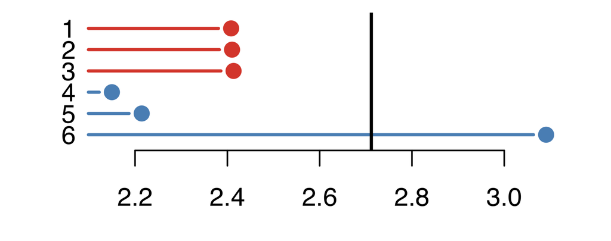

**Figure 1. Outlier detection for Distances between arrays.** Bar chart of the sum of distances to other arrays, one outlier detection method. A bar beyond the black line indicates the sample is an outlier. Sample 6, fav_stress_C has been detected as an outlier with this method.

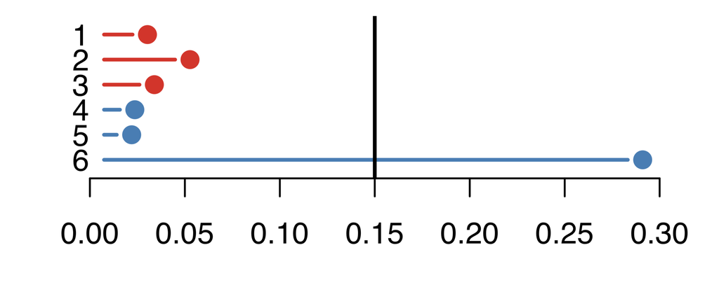

**Figure 2. Outlier detection for MA plots.** Bar chart of the sum of distances to other arrays, one outlier detection method. Bar chart of the Hoeffding’s statistic, Da, another outlier detection criterion. A bar beyond the black line indicates the sample is an outlier. Sample 6, fav_stress_C has been detected as an outlier with this method.

We next converted the counts data, treatment information, and desired statistical model into a DESeq object so that we can work with the data in DESeq.

```r
dds=DESeqDataSetFromMatrix(countData=countData,
                           colData = g,
                           design = ~treat)
vsd.ge=assay(vst(dds))
rl=vst(dds)
e=ExpressionSet(assay(rl), AnnotatedDataFrame(as.data.frame(colData(rl))))
arrayQualityMetrics(e, intgroup=c("treat"),force=T)
```

One step DESeq does the following: estimates size factors, estimates dispersions, generates gene-wise dispersion estimates, generates the mean-dispersion relationship, final dispersion estimates, and fits and tests the model.

```r
dds<-DESeq(dds)
```

```r
head(dds)
```

```
class: DESeqDataSet
dim: 6 6
metadata(1): version
assays(4): counts mu H cooks
rownames(6): symcomp10000 symcomp10001 ... symcomp10005 symcomp100051
rowData names(22): baseMean baseVar ... deviance maxCooks
colnames(6): fav_recoveryA fav_recoveryB ... fav_stressB fav_stressC
colData names(2): treat sizeFactor
```

```r
res<- results(dds)
res
```

```
log2 fold change (MLE): treat Stress vs Recovery
Wald test p-value: treat Stress vs Recovery
DataFrame with 31999 rows and 6 columns
              baseMean log2FoldChange     lfcSE      stat     pvalue      padj
             <numeric>      <numeric> <numeric> <numeric>  <numeric> <numeric>
symcomp10000   5.57964      -2.710724  0.888053 -3.052437 0.00226992 0.0976334
symcomp10001   7.63549      -0.649713  0.691254 -0.939905 0.34726642 0.7472023
symcomp10002   4.46386      -0.283695  0.834641 -0.339901 0.73393082 0.9341280
symcomp10003   7.84874      -0.137103  0.708906 -0.193400 0.84664558 0.9554695
symcomp10005   2.13457      -2.702317  1.533715 -1.761942 0.07807911        NA
...                ...            ...       ...       ...        ...       ...
symcomp9988    13.0498       -2.14724  0.676271  -3.17511 0.00149777  0.084357
symcomp9994     0.0000             NA        NA        NA         NA        NA
symcomp9995     0.0000             NA        NA        NA         NA        NA
symcomp99961    0.0000             NA        NA        NA         NA        NA
symcomp9997     0.0000             NA        NA        NA         NA        NA
```

Next, we generate a dispersion plot that visualizes what DESeq2 is doing to our data and fits it to this curve. The plot should look like a hockey stick, so this plot is adequate.

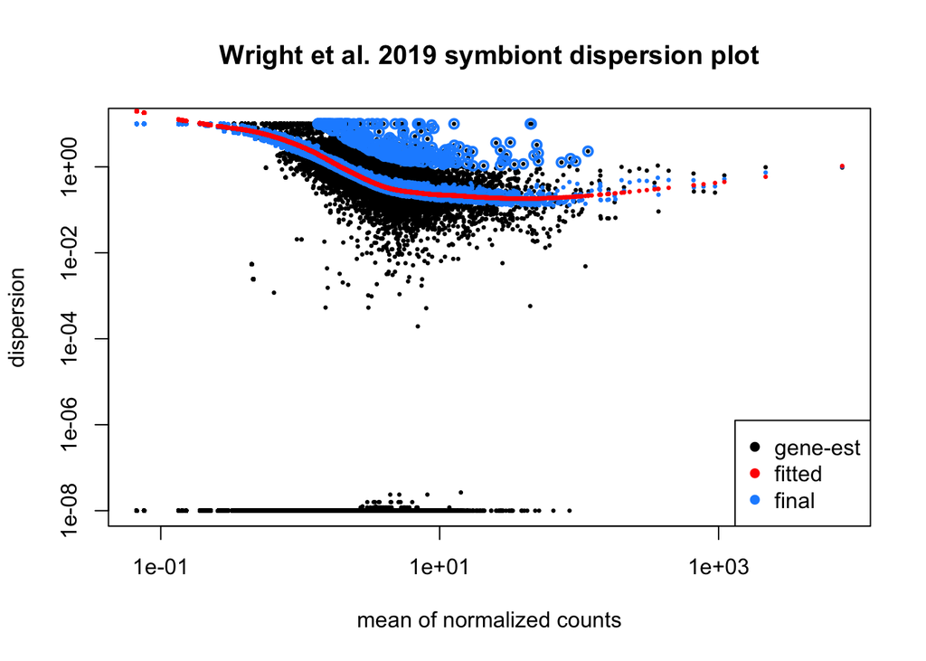

**Figure 3. Wright et al. 2019 symbiont dispersion plot.**

```r
plotDispEsts(dds, main="Wright et al. 2019 symbiont dispersion plot")
```

## **Stress vs. recovery comparison to identify differentially expressed genes**

We can only do pairwise comparisons. Levels are used because gene expression is always relative; the first term is the treatment and the second term is the one that’s relative (treatment 1st, control 2nd).

```r
colData$Stress<-factor(colData$treat, levels=c("Stress","Recovery"))
```

```r
resStress <- results(dds, contrast=c("treat","Stress","Recovery"))
```

False discovery rate pvalues are adjusted to < 10%

```r
table(resStress$padj<0.1)
```

```
FALSE  TRUE
 4972   121
```

```r
summary(resStress)
```

```
out of 23020 with nonzero total read count
adjusted p-value < 0.1
LFC > 0 (up)       : 23, 0.1%
LFC < 0 (down)     : 98, 0.43%
outliers [1]       : 4, 0.017%
low counts [2]     : 17923, 78%
(mean count < 3)
[1] see 'cooksCutoff' argument of ?results
[2] see 'independentFiltering' argument of ?results
```

A lot of genes were removed due to low counts; 0.1% of genes upregulated in stress relative to recovery, and 0.43% were downregulated under stress relative to recovery.

Below is another way to look at the number of significantly differentially expressed genes, excluding the no/low count genes.

```r
nrow(resStress[resStress$padj<0.1 & !is.na(resStress$padj),])
```

```
[1] 121
```

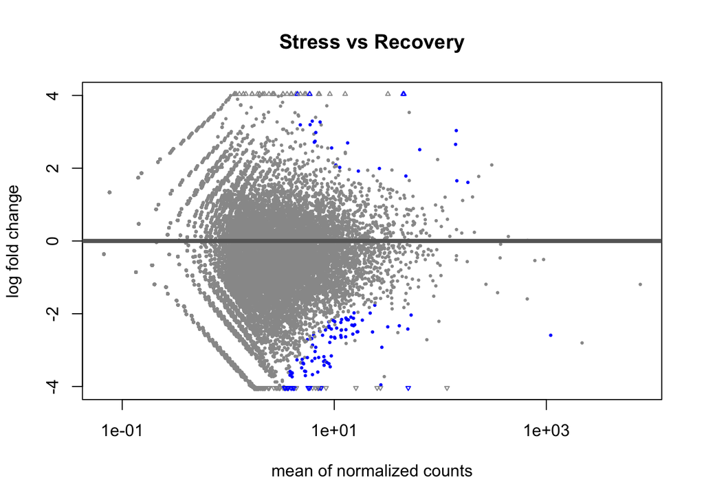

**Figure 4. MA plot.** The MA plot shows the mean of normalized counts. The X axis shows the means of the normalized gene counts, with lowly expressed genes to the left and highly expressed genes to the right. The Y axis shows the log fold change in gene expression. Negative log fold change is downregulated genes and postitive fold change is upregulated genes. The blue points represent differentially expressed genes.

```r
plotMA(resStress, main="Stress vs Recovery")
```

Our results are put in a data frame, ‘resStress’. We can look at the number of rows in the dataframe separated by up- or downregulated genes. 23 genes are upregulated and 98 genes are downregulated.

```r
results <- as.data.frame(resStress)
nrow(resStress[resStress$padj<0.1 & resStress$log2FoldChange > 0 & !is.na(resStress$padj),]) #no. genes upregulated
```

```
[1] 23
```

```r
nrow(resStress[resStress$padj<0.1 & resStress$log2FoldChange < 0 & !is.na(resStress$padj),]) #no. genes downregulated
```

```
[1] 98
```

We create a table from the ‘resStress’ dataframe. This is where we will pull our p-values and p-adjusted values from in later steps.

```r
write.table(resStress, file="StressvRecovery.txt", quote=F, sep="\t")
```

```r
cd <- read.table("StressvRecovery.txt")
```

## **Adjusting P-Values & Log Transforming Data**

We used the following code to create a table comparing the original p-values to the adjusted p-values. P-values are adjusted to reduce error.

```r
valStress=cbind(resStress$pvalue, resStress$padj)
colnames(valStress)=c("pval.Stress", "padj.Stress")
```

The total amount of p-values calculated, including samples with no or low counts, is 31999. This can be found using the following code:

```r
length(valStress[,1])
```

[output not shown]

```r
table(complete.cases(valStress))
```

[output not shown]

```r
dim(rldpvals)
```

```
[1] 31999    10
```

## **Data visualizations**

### Creating a Sample Distance Heatmap

Using the RColorBrewer and gplots packages, a heatmap of sample distances was created.

[output not shown]

[output not shown]

[output not shown]

[output not shown]

[output not shown]

[output not shown]

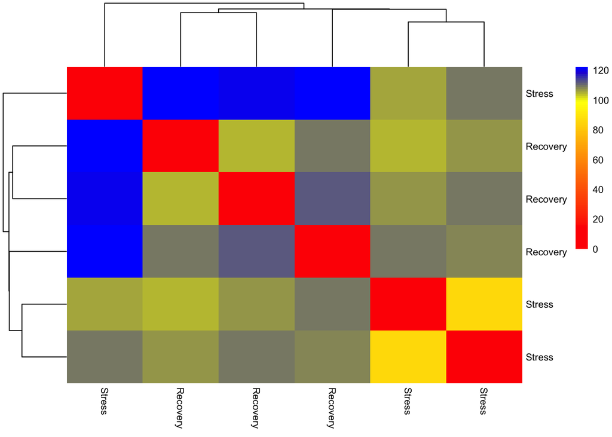

**Figure 5. Sample comparison heatmap** This heatmap depicts a comparison between genes found in each of the six sampling locations, in either Stress or Recovery periods, and quantifies their degree of similarity in expression. A value near zero indicates similarity between samples, and a higher number indicates a greater degree of difference. Two stress samples act similarly and cluster together, displaying a strong signature. The third stress sample does not cluster, suggesting that it’s an outlier.

### Principal Components Analysis

Next, we run a Principal Components Analysis (PCA) to see how the gene expression of each of our 6 samples group together based on similarity.

```r
rld_t=t(rld)
pca <- prcomp(rld_t,center = TRUE)
li <- pca$sdev^2 / sum(pca$sdev^2)
pc1v <- round(li[1] * 100, 1)
pc2v <- round(li[2] * 100, 1)
pca_s <- as.data.frame(pca$x)
head(pca_s)
```

```
                 PC1        PC2       PC3        PC4        PC5           PC6
Recovery   -32.04186  54.378668 -38.61630  -4.061681  -4.208409  9.635211e-13
Recovery.1 -37.95437 -18.424555  17.21415  54.433164   4.599261  9.976583e-13
Recovery.2 -32.19458 -48.683903 -14.98946 -40.264154   1.077195 -1.476987e-12
Stress      19.99107   8.124355  34.76896  -9.201757 -45.646645  1.968511e-14
Stress.1    17.19334  20.623117  39.05035 -18.454495  39.423740  4.878359e-13
Stress.2    65.00639 -16.017681 -37.42770  17.548923   4.754858 -9.906339e-13
```

The above table shows us the coordinates of each sample on each of the 6 principal components. The principal components 1 through 6 explain decreasing amounts of variation in the data, with 1 explaining the most variation and 6 the least. We select out the first two principal components below so that we can plot the PCA on 2 axes.

```r
pca_s <- pca_s[,c(1,2)]
pca_s$Samples = row.names(pca_s)
pca_s$treat=colData$treat
head(pca_s)
```

```
                 PC1        PC2    Samples    treat
Recovery   -32.04186  54.378668   Recovery Recovery
Recovery.1 -37.95437 -18.424555 Recovery.1 Recovery
Recovery.2 -32.19458 -48.683903 Recovery.2 Recovery
Stress      19.99107   8.124355     Stress   Stress
Stress.1    17.19334  20.623117   Stress.1   Stress
Stress.2    65.00639 -16.017681   Stress.2   Stress
```

The above table contains our final coordinates for each sample on the principal component axes. We next plot the PCA below.

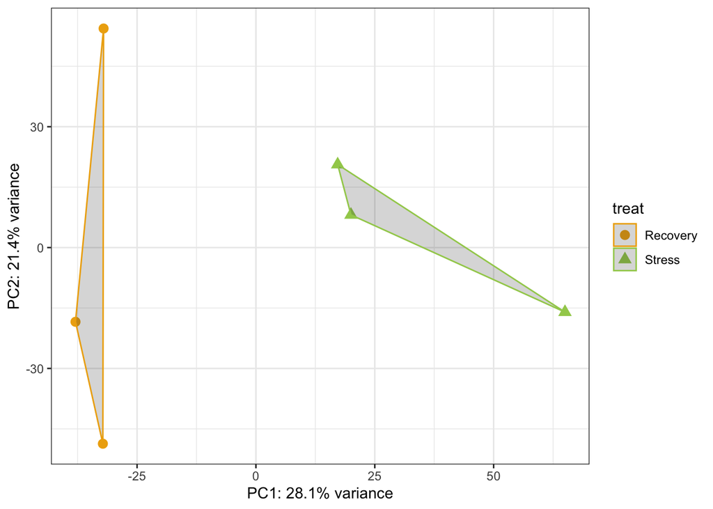

**Figure 6. Principal components analysis of gene expression of stress vs recovery samples.** PC1 explains 28.1% of the variance and PC2 explains 21.4% of the variance, for a total of 49.5% of variance explained by the first two principal components. The gene expression of the samples groups by stress vs recovery.

```r
cbPalette <- c("darkgoldenrod2",  "darkolivegreen3", "dodgerblue3")
ggplot(pca_s, aes(PC1, PC2, color = treat, pch = treat)) +
  geom_point(size=3) +
  #  geom_text_repel(aes(label=Samples)) +
  scale_colour_manual(values=cbPalette)+
  theme_bw() +
  # geom_density2d(alpha=.5)+
  geom_polygon(alpha=.2)+
  xlab(paste0("PC1: ",pc1v,"% variance")) +
  ylab(paste0("PC2: ",pc2v,"% variance"))
```

From this plot, we can see that the symbiont gene expression of the samples groups by treatment (stress vs. recovery). Together, the first two principal components explain 49.5% of the variance in the data. The percentage of variance explained is likely low because we only included 6 samples in the analysis.

To see if the clustering of gene expression of the two treatments on the principal component axes is significantly different, we run an analysis of variance with distance matrices.

```r
adonis(pca$x ~ treat, data = pca_s, method='eu', na.rm = TRUE)
```

```
Call:
adonis(formula = pca$x ~ treat, data = pca_s, method = "eu",      na.rm = TRUE)

Permutation: free
Number of permutations: 719

Terms added sequentially (first to last)

          Df SumsOfSqs MeanSqs F.Model      R2 Pr(>F)
treat      1    8022.4  8022.4  1.4587 0.26723    0.1
Residuals  4   21998.1  5499.5         0.73277
Total      5   30020.5                 1.00000
```

This output tells us that the P-value [“Pr(>F)”] is 0.1. Thus, the two treatments are not significantly different, but are marginally different. However, because of our low sample size and strong visual clustering of treatments on the plotted PCA, we conclude that there is likely a difference in the gene expression of coral symbionts in the stressed versus recovery conditions.

To create heatmaps to visualize the gene expression across our samples, we take the P-values and Rlog data, and read in the .csv with gene annotations.

```r
setwd("~/Desktop/BU/PhD/Spring_2021_classes/Ecological_genomics/Assign2/Project4")
rldpvals <- read.csv(file="RLDandPVALS.csv", row.names=1)
rld_site= rldpvals[,1:6]
gg=read.table("Bmin_iso2gene.tab",sep="\t", row.names=1)
nrow(rldpvals[rldpvals$padj.Stress<0.1& !is.na(rldpvals$padj.Stress),])
```

```
[1] 121
```

The above output displays how many differentially expressed genes we have using a p-value threshold of 0.1: 121 genes. We picked 0.1 as the P-value cutoff because we have very few samples, so we will not find many significantly differentially expressed genes with a very strict P-value.

### Heatmap with all differentially expressed genes

121 differentially expressed genes is a manageable number of genes to visualize, so we created a heatmap with all the differentially expressed genes.

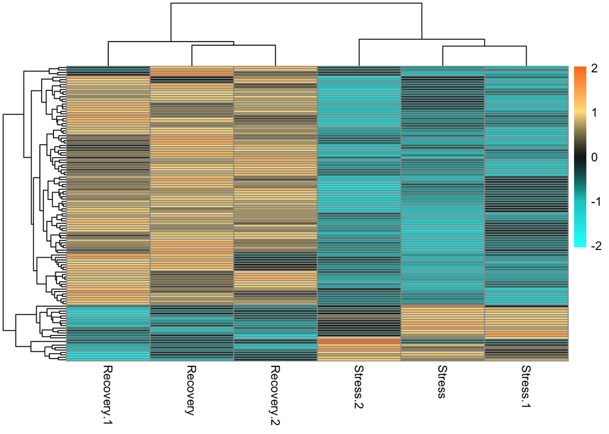

**Figure 7. Heatmap of all differentially expressed genes between stress and recovery conditions.** Each row of rectangles represents one differentially expressed gene. The x axis shows the 6 samples analyzed. The legend displays the level of up- or downregulation. 2 (orange) indicates that the gene is more upregulated relative to the other treatment, while -2 (teal) indicates that the gene is more downregulated relative to the other treatment. 121 genes were differentially expressed with a p-value cutoff of 0.1. For the majority of differentially expressed genes, they were upregulated during recovery relative to stress conditions.

```r
p.val=0.1 #this is the False Discovery Rate cutoff
conds=rldpvals[rldpvals$padj.Stress<=p.val & !is.na(rldpvals$padj.Stress) & rldpvals$padj.Stress<=p.val & !is.na(rldpvals$padj.Stress),]
rld_data= conds[,c(1:6)]
library(pheatmap)
means=apply(rld_data,1,mean) # means of rows
explc=rld_data-means # subtracting them

ccol=colorRampPalette(rev(c("red","chocolate1","#FEE090","grey10", "cyan3","cyan")))(100)
col0=colorRampPalette(rev(c("chocolate1","#FEE090","grey10", "cyan3","cyan")))(100)

pheatmap(explc,cluster_cols=T,scale="row",color=col0, show_rownames = F)
```

This figure shows that for the majority of differentially expressed genes, they were upregulated during recovery relative to stress conditions. However, there is a small chunk of genes that were upregulated under stress relative to recovery conditions (in the bottom of the heatmap).

### Heatmap with annotated genes

First, we generated the heatmap with the p-value cutoff of 0.01 without annotations. 6 genes are differentially expressed with a p-value of 0.01.

```r
p.val=0.01 # changing the False Discovery Rate cutoff
conds=rldpvals[rldpvals$padj.Stress<=p.val & !is.na(rldpvals$padj.Stress) & rldpvals$padj.Stress<=p.val & !is.na(rldpvals$padj.Stress),]
rld_data= conds[,c(1:6)]
head(rld_data)
```

```
               Recovery Recovery.1 Recovery.2    Stress   Stress.1 Stress.2
symcomp18723  5.6719508   4.120079  5.8095387  1.129635  3.0839957 2.027262
symcomp19617 -0.5268931  -1.195874 -0.5221644 -1.110338 -0.7024751 7.196444
symcomp27355 -0.5231868  -1.193124 -0.5184501 -1.107480 -0.6990490 7.219013
symcomp34132  4.7572990   5.973647  5.2683997  3.609056  2.5876500 2.250543
symcomp44259  4.2576386   4.002615  4.9941359  6.864185  6.7680563 5.972768
symcomp64616  7.1821494   3.211360  6.0369028  2.682536  2.7615953 3.387478
```

```r
nrow(rld_data)
```

```
[1] 6
```

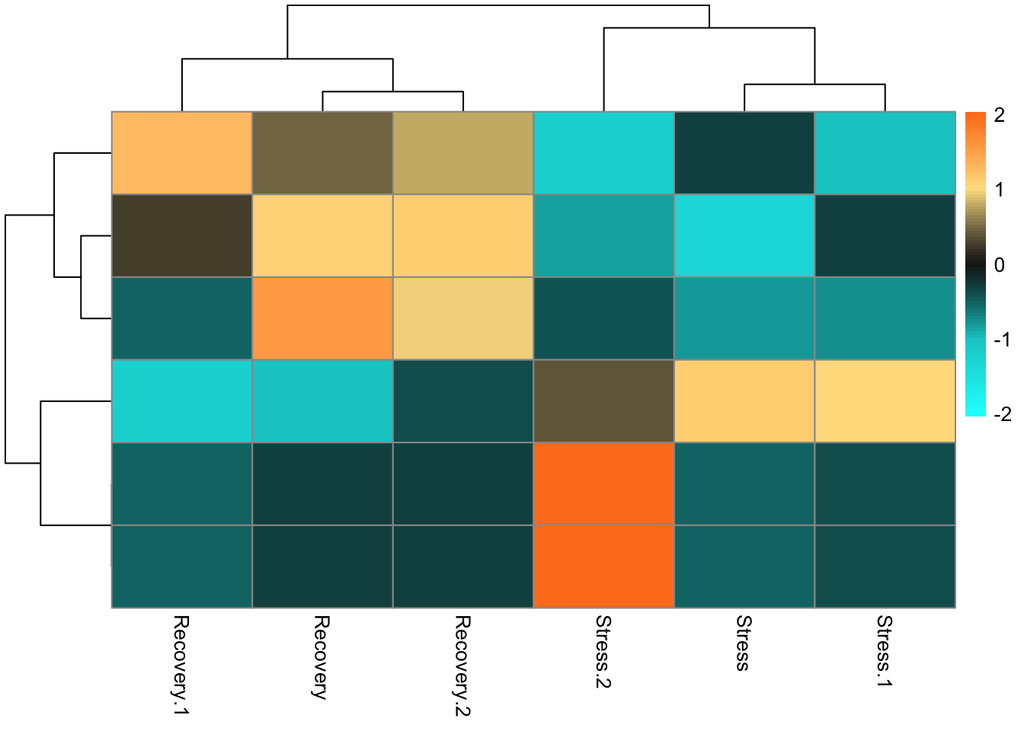

```r
library(pheatmap)
means=apply(rld_data,1,mean) # means of rows
explc=rld_data-means # subtracting them

ccol=colorRampPalette(rev(c("red","chocolate1","#FEE090","grey10", "cyan3","cyan")))(100)
col0=colorRampPalette(rev(c("chocolate1","#FEE090","grey10", "cyan3","cyan")))(100)

pheatmap(explc,cluster_cols=T,scale="row",color=col0, show_rownames = F)
```

Next, we added gene annotations and set colors with the following code.

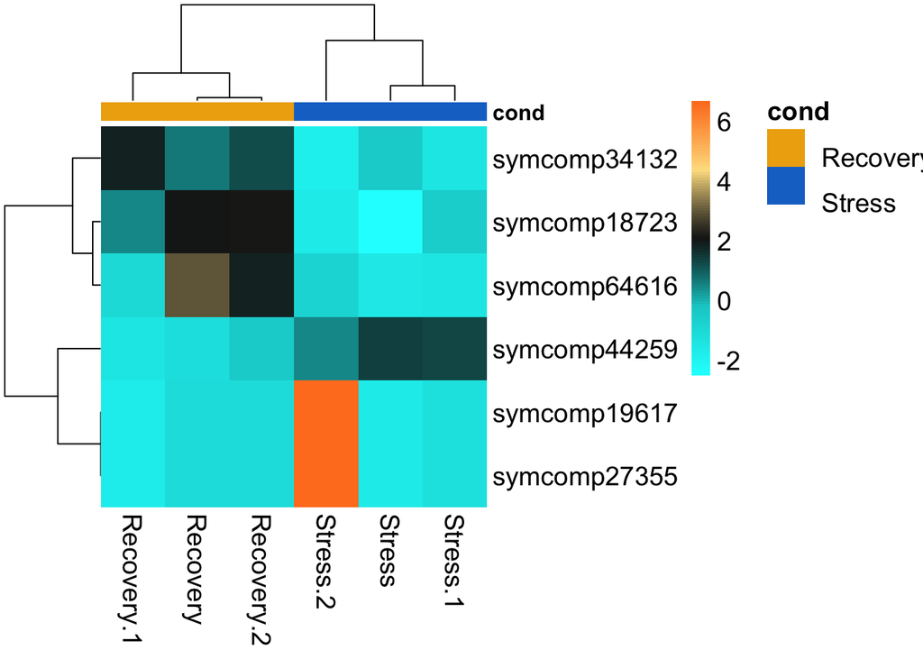

```r
ann = data.frame(cond = c('Recovery', 'Recovery', 'Recovery', 'Stress', 'Stress', 'Stress'))
rownames(ann) <- names(explc)

Var1        <- c("darkgoldenrod2","dodgerblue3")
names(Var1) <- c("Recovery", "Stress")
anno_colors <- list(cond = Var1)

pheatmap(as.matrix(explc),annotation_col=ann,annotation_colors=anno_colors,cex=1.2,color=col0,border_color=NA,clustering_distance_rows="correlation",clustering_distance_cols="correlation", show_rownames=T)
```

In this figure, we see that 3 of 6 genes are more upregulated in the recovery relative to the stress conditions. Two genes are highly upregulated in just one of the stressed samples. One gene is upregulated in all stressed samples relative to the recovery samples.

## Conclusion

Our findings indicate that gene expression of algal symbionts groups by recovery vs. stress conditions. The majority of differentially expressed genes are upregulated during recovery relative to stress conditions, indicating that recovery following stressful periods leads to upregulation of symbiont gene pathways. Overall, our findings suggest that algal symbionts of coral hosts enact different gene expression pathways when exposed to and recovering from stressful events.